# JOINING DATA WITH DPLYR: FULL, SEMI AND ANTI JOINS

Load the **tidyverse** packages and read the tables:

```r
library(tidyverse)
inventories <- readRDS("inventories.rds")
inventory_parts <- readRDS("inventory_parts.rds")
```

Combine **inventories** and **inventory_parts** using `inner_join`:

```r
inventory_parts_joined <- inventories %>%
  inner_join(inventory_parts, by = c("id" = "inventory_id")) %>%
 select(-id, -version) %>%
  arrange(desc(quantity))
inventory_parts_joined
```

```
## # A tibble: 258,958 x 4
##    set_num  part_num color_id quantity
##    <chr>    <chr>       <dbl>    <dbl>
##  1 40179-1  3024           72      900
##  2 40179-1  3024           15      900
##  3 40179-1  3024            0      900
##  4 40179-1  3024           71      900
##  5 40179-1  3024           14      900
##  6 k34434-1 3024           15      810
##  7 21010-1  3023          320      771
##  8 k34431-1 3024            0      720
##  9 42083-1  2780            0      684
## 10 k34434-1 3024            0      540
## # ... with 258,948 more rows
```

Extract again just 2 LEGO sets “Batmobile” and “Batwing”:

```r
batmobile <- inventory_parts_joined %>%
  filter(set_num == "7784-1") %>%
  select(-set_num)
batwing <- inventory_parts_joined %>%
  filter(set_num == "70916-1") %>%
  select(-set_num)
```

### 7.1 The full_join verb

With left join or right join, we can see which pieces were in one but not the other? What if you want to keep all observations in both tables, whether or not they match to each other? The `full_join` verb in **dplyr** allows us to do that.

[figure not shown]

A left join would keep all the observations in batmobile, a right join would keep all the observations in batwing. A full join keeps all the observations in either. All other arguments like `by` and `suffix` stay the same.

```r
batmobile %>%
  full_join(batwing, by = c("part_num", "color_id"),
            suffix = c("_batmobile", "_batwing"))
```

```
## # A tibble: 440 x 4
##    part_num color_id quantity_batmobile quantity_batwing
##    <chr>       <dbl>              <dbl>            <dbl>
##  1 3023           72                 62               NA
##  2 2780            0                 28               17
##  3 50950           0                 28                2
##  4 3004           71                 26                2
##  5 43093           1                 25                6
##  6 3004            0                 23                4
##  7 3010            0                 21               NA
##  8 30363           0                 21               NA
##  9 32123b         14                 19               NA
## 10 3622            0                 18                2
## # ... with 430 more rows
```

The result of full join has 440 observations, which is more than either of the tables originally. A full join is like opening both the boxes of Batmobile and Batwing and pour all the pieces out next to one another!

There are `NA` in both `quantity_batmobible` and `quantity_batwing` columns. Replace `NA` with `0`:

```r
batmobile %>%
  full_join(batwing, by = c("part_num", "color_id"),
            suffix = c("_batmobile", "_batwing")) %>%
  replace_na(list(quantity_batmobile = 0, quantity_batwing = 0)) # replace NAs in multiple variables by separating them with commas.
```

```
## # A tibble: 440 x 4
##    part_num color_id quantity_batmobile quantity_batwing
##    <chr>       <dbl>              <dbl>            <dbl>
##  1 3023           72                 62                0
##  2 2780            0                 28               17
##  3 50950           0                 28                2
##  4 3004           71                 26                2
##  5 43093           1                 25                6
##  6 3004            0                 23                4
##  7 3010            0                 21                0
##  8 30363           0                 21                0
##  9 32123b         14                 19                0
## 10 3622            0                 18                2
## # ... with 430 more rows
```

### 7.2 Compare Batman and Star Wars

Now we compare two **themes**, each is made up of many **sets**.

```r
themes <- readRDS("themes.rds")
sets <- readRDS("sets.rds")
```

Combine the **sets** table with `inventory_parts_joined`, then combine **themes**:

```r
inventory_parts_joined %>%
  inner_join(sets, by = "set_num") %>%
  inner_join(themes, by = c("theme_id" = "id"),
             suffix = c("_set", "_theme"))
```

```
## # A tibble: 258,958 x 9
##    set_num part_num color_id quantity name_set  year theme_id name_theme
##    <chr>   <chr>       <dbl>    <dbl> <chr>    <dbl>    <dbl> <chr>
##  1 40179-1 3024           72      900 Persona~  2016      277 Mosaic
##  2 40179-1 3024           15      900 Persona~  2016      277 Mosaic
##  3 40179-1 3024            0      900 Persona~  2016      277 Mosaic
##  4 40179-1 3024           71      900 Persona~  2016      277 Mosaic
##  5 40179-1 3024           14      900 Persona~  2016      277 Mosaic
##  6 k34434~ 3024           15      810 Lego Mo~  2003      277 Mosaic
##  7 21010-1 3023          320      771 Robie H~  2011      252 Architect~
##  8 k34431~ 3024            0      720 Lego Mo~  2003      277 Mosaic
##  9 42083-1 2780            0      684 Bugatti~  2018        5 Model
## 10 k34434~ 3024            0      540 Lego Mo~  2003      277 Mosaic
## # ... with 258,948 more rows, and 1 more variable: parent_id <dbl>
```

```r
inventory_sets_themes <- inventory_parts_joined %>%
  inner_join(sets, by = "set_num") %>%
  inner_join(themes, by = c("theme_id" = "id"),
             suffix = c("_set", "_theme"))
```

Since each theme is made up of many sets, combining these tables is the first step towards being able to compare different themes.

Filter the themes for “Batman” and “Star Wars”:

```r
batman <- inventory_sets_themes %>%
  filter(name_theme == "Batman")
star_wars <- inventory_sets_themes %>%
  filter(name_theme == "Star Wars")
```

Before comparing the tables, we aggregate the data to learn more about the pieces that are a part of each theme, as well as the colors of those pieces. Count the `part_number` and `color_id`, weight by `quantity`:

```r
batman_parts <- batman %>%
  count(part_num, color_id, wt = quantity)
star_wars_parts <- star_wars %>%
  count(part_num, color_id, wt = quantity)
```

Now that we have got separate tables for the pieces in the Batman and Star Wars themes, we can combine them to see any similarities or differences between two themes.

```r
parts_joined <- batman_parts %>%
  full_join(star_wars_parts, by = c("part_num", "color_id"),
            suffix = c("_batman", "_star_wars")) %>%
  replace_na(list(n_batman = 0, n_star_wars = 0))
```

The result is a comprehensive table that includes the part number, color id, and quantity of each piece in the Batman and Star Wars themes!

However, we have more information about each of these parts that we can gain by combining this table with some of the information we have in other tables. Before we compare the themes, let’s ensure that we have enough information to make our findings more interpretable.

```r
colors <-readRDS("colors.rds")
parts <- readRDS("parts.rds")
parts_joined %>%
  arrange(desc(n_star_wars)) %>%
  inner_join(colors, by = c("color_id" = "id")) %>%
  inner_join(parts, by = "part_num", suffix = c("_color", "_part"))
```

```
## # A tibble: 3,628 x 8
##    part_num color_id n_batman n_star_wars name_color rgb   name_part part_cat_id
##    <chr>       <dbl>    <dbl>       <dbl> <chr>      <chr> <chr>           <dbl>
##  1 2780            0      104         392 Black      #051~ Technic ~          53
##  2 32062           0        1         141 Black      #051~ Technic ~          46
##  3 4274            1       56         118 Blue       #005~ Technic ~          53
##  4 6141           36       11         117 Trans-Red  #C91~ Plate Ro~          21
##  5 3023           71       10         106 Light Blu~ #A0A~ Plate 1 ~          14
##  6 6558            1       30         106 Blue       #005~ Technic ~          53
##  7 43093           1       44          99 Blue       #005~ Technic ~          53
##  8 3022           72       14          95 Dark Blui~ #6C6~ Plate 2 ~          14
##  9 2357           19        0          84 Tan        #E4C~ Brick 2 ~          11
## 10 6141          179       90          81 Flat Silv~ #898~ Plate Ro~          21
## # ... with 3,618 more rows
```

You can now see the pieces side by side from each of these themes. Since the pieces are sorted by number of Star Wars pieces in descending order, you can see that the most common Star Wars piece is Black and has the part number 2780. While there are 392 pieces of this part in the Star Wars theme, you can also see from the table that there are 104 pieces of the same part in the Batman theme.

### 7.3 Semi and Anti join

All the verbs `inner_join`, `left_join`, `right_join` and `full_join` belong to the *mutating verbs*; they combine variables from two tables. Another class of verbs is the *filtering joins*. A filtering join keeps observations from the first table but doesn’t add new variables. `semi_join` and `anti_join` are two filtering verbs.

[figure not shown]

- `semi_join` asks the question “What observations in first table are also in second table?”
- `anti_join` is the opposite of `semi-join`, asking the question “What observations in the first table are not in the second table?”

For example, what parts are used in Batmobile are also used in Batwing?

```r
batmobile %>%
  semi_join(batwing, by = c("color_id", "part_num"))
```

```
## # A tibble: 45 x 3
##    part_num color_id quantity
##    <chr>       <dbl>    <dbl>
##  1 2780            0       28
##  2 50950           0       28
##  3 3004           71       26
##  4 43093           1       25
##  5 3004            0       23
##  6 3622            0       18
##  7 4286            0       16
##  8 3039            0       12
##  9 4274           71       12
## 10 3001            0       11
## # ... with 35 more rows
```

The `semi_join` reduces from 173 pieces in the Batmobile to 45 pieces that are also in the Batwing set. But notice that we still have the same variables that the Batmobile set started with. We do not even need to specify a suffix. This is useful when we want to filter down a table without modifying it further.

Conversely, what pieces are in the Batmobile set but not in the Batwing? To anwer this, we use `anti_join`.

```r
batmobile %>%
  anti_join(batwing, by = c("color_id", "part_num"))
```

```
## # A tibble: 128 x 3
##    part_num color_id quantity
##    <chr>       <dbl>    <dbl>
##  1 3023           72       62
##  2 3010            0       21
##  3 30363           0       21
##  4 32123b         14       19
##  5 50950         320       18
##  6 6541            0       18
##  7 3040b           0       14
##  8 3298            0       14
##  9 3660            0       14
## 10 42022           0       14
## # ... with 118 more rows
```

The `anti_join` tells us there are 128 pieces in the Batmobile that are not in the Batwing.

These verbs are not just useful to compare batman’s rides, they could be used to filter down the other tables we have work with. For example, you may want to know what themes ever appear in a set.

```r
themes %>%
  semi_join(sets, by = c("id" = "theme_id"))
```

```
## # A tibble: 569 x 3
##       id name           parent_id
##    <dbl> <chr>              <dbl>
##  1     1 Technic               NA
##  2     2 Arctic Technic         1
##  3     3 Competition            1
##  4     4 Expert Builder         1
##  5     5 Model                  1
##  6     6 Airport                5
##  7     7 Construction           5
##  8     9 Fire                   5
##  9    10 Harbor                 5
## 10    11 Off-Road               5
## # ... with 559 more rows
```

Conversely, find themes that never appear in a set in the database:

```r
themes %>%
  anti_join(sets, by = c("id" = "theme_id"))
```

```
## # A tibble: 96 x 3
##       id name         parent_id
##    <dbl> <chr>            <dbl>
##  1     8 Farm                 5
##  2    24 Airport             23
##  3    25 Castle              23
##  4    26 Construction        23
##  5    27 Race                23
##  6    28 Harbor              23
##  7    29 Train               23
##  8    32 Robot               23
##  9    34 Building            23
## 10    35 Cargo               23
## # ... with 86 more rows
```

Besides comparing two sets directly, you could also use a filtering join like `semi_join` to find out which colors ever appear in any inventory part. Some of the colors could be optional, meaning they aren’t included in any sets.

```r
colors %>%
  semi_join(inventory_parts, by = c("id" = "color_id"))
```

```
## # A tibble: 134 x 3
##       id name           rgb
##    <dbl> <chr>          <chr>
##  1    -1 [Unknown]      #0033B2
##  2     0 Black          #05131D
##  3     1 Blue           #0055BF
##  4     2 Green          #237841
##  5     3 Dark Turquoise #008F9B
##  6     4 Red            #C91A09
##  7     5 Dark Pink      #C870A0
##  8     6 Brown          #583927
##  9     7 Light Gray     #9BA19D
## 10     8 Dark Gray      #6D6E5C
## # ... with 124 more rows
```

Out of the 179 colors in the **colors** table, there are 134 colors that are included in at least one set.

Each set included in the LEGO data has an associated version number. We want to understand the version we are looking at to learn more about the parts that are included. Before doing that, we should confirm that there aren’t any sets that are missing a particular version. For example, find out which set is missing version 1:

```r
version_1_inventories <- inventories %>%
  filter(version == 1)
sets %>%
  anti_join(version_1_inventories, by = "set_num")
```

```
## # A tibble: 1 x 4
##   set_num name       year theme_id
##   <chr>   <chr>     <dbl>    <dbl>
## 1 40198-1 Ludo game  2018      598
```

This is likely a data quality issue, and `anti_join` is a great tool for finding problems like that.

### 7.4 Visualize set differences

Let’s say instead of working with pieces, you want to examine and compare the colors used in each set. This will take a little effort, but it will make a great and intuitive visualizations of the differences in the color palettes between Batmobile and Batwing.

Before doing any joining, first aggregate each set into colors.

```r
batmobile_colors <- batmobile %>%
  group_by(color_id) %>%
  summarize(total = sum(quantity))
batwing_colors <- batwing %>%
  group_by(color_id) %>%
  summarize(total = sum(quantity))
```

Now we have two tables where each has one observation per color.

```r
batmobile_colors
```

```
## # A tibble: 12 x 2
##    color_id total
##       <dbl> <dbl>
##  1        0   543
##  2        1    33
##  3        4    16
##  4       14    20
##  5       15    16
##  6       36    15
##  7       57     8
##  8       71   202
##  9       72   160
## 10      182     8
## 11      297     4
## 12      320    27
```

```r
batwing_colors
```

```
## # A tibble: 20 x 2
##    color_id total
##       <dbl> <dbl>
##  1        0   418
##  2        1    45
##  3        4    81
##  4       14    22
##  5       15    22
##  6       19    10
##  7       25     1
##  8       34     3
##  9       36     9
## 10       46    21
## 11       47     4
## 12       52     4
## 13       57     3
## 14       70    16
## 15       71   158
## 16       72   213
## 17       78     3
## 18       80     4
## 19      179     1
## 20      182    14
```

Combine two tables and replace `NA` with zero:

```r
colors_joined <- batmobile_colors %>%
  full_join(batwing_colors, by = "color_id",
            suffix = c("_batmobile", "_batwing")) %>%
  replace_na((list(total_batmobile = 0, total_batwing = 0)))
```

The tables have only the color ID right now, so we will join in the color names from the **colors** table.

```r
colors_joined <- colors_joined %>%
  inner_join(colors, by = c("color_id" = "id"))
```

The two quantities are still hard to compare because the two sets have different total numbers of pieces. Normalize each of the colors by turning them into fraction of the total:

```r
colors_joined <- colors_joined %>%
  mutate(total_batmobile = total_batmobile/sum(total_batmobile),
         total_batwing = total_batwing/sum(total_batwing),
         difference = total_batmobile - total_batwing) # difference between two fractions.
```

See the result after processing the joined data:

```r
colors_joined
```

```
## # A tibble: 22 x 6
##    color_id total_batmobile total_batwing name              rgb     difference
##       <dbl>           <dbl>         <dbl> <chr>             <chr>        <dbl>
##  1        0         0.516         0.397   Black             #05131D    0.119
##  2        1         0.0314        0.0428  Blue              #0055BF   -0.0114
##  3        4         0.0152        0.0770  Red               #C91A09   -0.0618
##  4       14         0.0190        0.0209  Yellow            #F2CD37   -0.00190
##  5       15         0.0152        0.0209  White             #FFFFFF   -0.00570
##  6       36         0.0143        0.00856 Trans-Red         #C91A09    0.00570
##  7       57         0.00760       0.00285 Trans-Neon Orange #FF800D    0.00475
##  8       71         0.192         0.150   Light Bluish Gray #A0A5A9    0.0418
##  9       72         0.152         0.202   Dark Bluish Gray  #6C6E68   -0.0504
## 10      182         0.00760       0.0133  Trans-Orange      #F08F1C   -0.00570
## # ... with 12 more rows
```

Now we can easily see which colors are more represented in one set or the other.

Visualizing data using **ggplot2** and **forcats** in tidyverse packages:

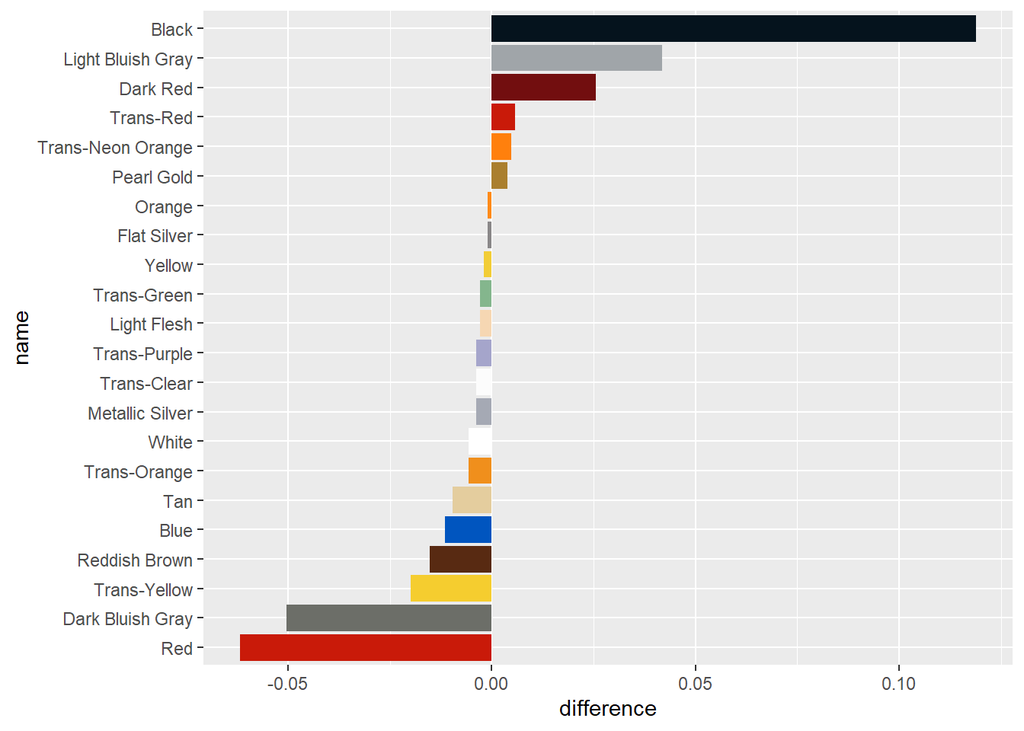

```r
color_palette <- setNames(colors_joined$rgb, colors_joined$name)
colors_joined %>%
  mutate(name = fct_reorder(name, difference)) %>%
  ggplot(aes(name, difference, fill = name)) +
  geom_col() +
  coord_flip() +
  scale_fill_manual(values = color_palette, guide = FALSE)
```

The color bars on the right have positive differences, meaning they are more common in the Batmobile set. The colors on the left are more common in the Batwing set.

### 7.5 Compare Batman and Star Wars sets

To compare two individual sets, and the kinds of LEGO pieces that comprise them, we will need to aggregate the data into separate themes.

```r
inventory_parts_themes <- inventories %>%
  inner_join(inventory_parts, by = c("id" = "inventory_id")) %>%
  arrange(desc(quantity)) %>%
  select(-id, -version) %>%
  inner_join(sets, by = "set_num") %>%
  inner_join(themes, by = c("theme_id" = "id"), suffix = c("_set", "_theme"))
```

Examine and compare colors using in Batman and Star Wars sets:

```r
batman_colors <- inventory_parts_themes %>%
  filter(name_theme == "Batman") %>%
  group_by(color_id) %>%
  summarize(total = sum(quantity)) %>%
 # add a percent column of the total divided by the sum of the total
  mutate(percent = total/sum(total))
```

Repeat the steps to filter and aggregate the Star Wars set:

```r
star_wars_colors <- inventory_parts_themes %>%
  filter(name_theme == "Star Wars") %>%
  group_by(color_id) %>%
  summarize(total = sum(quantity)) %>%
  mutate(percent = total/sum(total))
```

In addition to being able to view the sets for Batman and Star Wars separately, adding the column also allowed us to be able to look at the percentage differences between the sets, rather than only being able to compare the numbers of pieces.

Combining these two sets to be able to compare the themes’ colors:

```r
colors_joined <- batman_colors %>%
  full_join(star_wars_colors, by = "color_id",
            suffix = c("_batman", "_star_wars")) %>%
  replace_na(list(total_batman = 0, total_star_wars = 0)) %>%
  inner_join(colors, by = c("color_id" = "id")) %>%
  # create the difference and total columns
  mutate(difference = percent_batman - percent_star_wars,
         total = total_batman + total_star_wars) %>%
  # add a filter to select observations where total is at least 200
  filter(total >= 200) %>%
  mutate(name = fct_reorder(name, difference))
```

With this combined table that contains all the information from the **batman_colors** and **star_wars_colors** tables, you can now create an informative visualization to compare the colors of these sets.

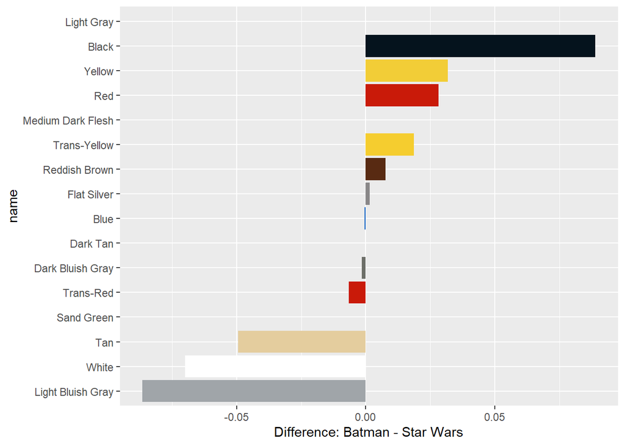

```r
ggplot(colors_joined,
       aes(name, difference,
           fill = name)) +
  geom_col() +
  coord_flip() +
  scale_fill_manual(values = color_palette, guide = FALSE) +
  labs(y = "Difference: Batman - Star Wars")
```